# Block Maxima Methods for Extreme Snowfall Events

## Return Levels

Some of the most important quantities in any extreme values analysis are the return levels. The return level for an associated return period of $K$ years is the expected level that is to be exceeded on average once over the following $K$ years. In the case of annual maximums we have the return level $X_k$ for a period of $K$ years defined as

$$\begin{equation}
\label{eq: gev_return}
X_k = \begin{cases}
\mu - \frac{\sigma}{\xi}\left[1 - \{ - ln(1-K^{-1})\}^{-\xi}\right] \ \text{if} \ \xi \ne 0 \\
\mu - \sigma\left[- ln(1-K^{-1})\right] \ \text{if} \ \xi = 0 \\
\end{cases}
\end{equation}$$

Invoking the invariance property of MLEs, we can solve for the MLE of the return level $\hat{X}_k$ by simply substituting the MLEs for $(\mu,\sigma,\xi)$ attained through Newton-Raphson.

## Smith’s Method for Spatial and Temporal Dependence

Snowfall data collected from stations close in proximity to one another will inevtiably exhibit spatial correlation. To account for this spatial correlation in our standard errors, we can employ a method devised by Smith Smith (1990) where MLE estimates are attained under the standard IID assumption and then standard errors are corrected in a post-hoc fashion to account for spatial dependence. . Furthermore, for block maxima methods, temporal dependence is typically not an issue since annual maxima tend to be separated by a large gap of time. To confirm this,we calculate the ACF of the annual maxima series for each station and find that there is no statistically significant auto-correlation for the $\alpha = 0.05$ level.

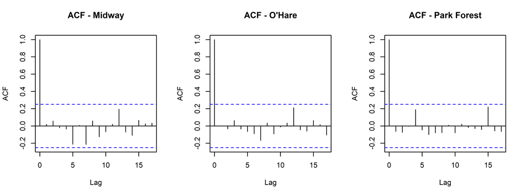

## Bootstrap CI for Return Levels

For GEV models, Rust (2011) note that asymptotic standard errors attained via the delta method are often inadequate in estimating the sampling variability of MLE estimators for return levels. Lee and Lee (2020) propose bootstrapping the confidence intervals for return levels using the standard percentile method where we use the $\alpha/2$ upper and lower quantiles of the bootstrapped return level estimates. Because the distribution of return levels tends to exhibit right-skew, therefore, standard bootstrap methods will be biased. To remedy this bias in bootstrap return level estimates, we can employ the (BCa) bootstrap methods introduced by Efron (1987). Suppose that we wish to generate $B$ bootsrap estimates of return level $X_k$. The BCa method works by first calculating the bias correction estimate $z_{BC}$

$$\begin{equation}
\label{eq: zbc}
z_bc = \Phi^{-1}\left(\frac{1}{B}\sum_{b = 1}^{B}I\left(\hat{x}^{(b)}_K < \hat{x}_K\right)\right)
\end{equation}$$

where $\Phi(.)$ is the standard normal CDF, $I(.)$ is the indicator function, and $\hat{x}_k$ denotes the MLE of the return level for period $K$ using the original data. Next, we calculate the acceleration constant $c_A$ which is defined as

$$\begin{equation}
\label{eq: acceleration}
c_A = \frac{\sum_{t=1}^{n}\left(\tilde{x}^{-t}_K - \tilde{x}_K\right)^3}{6\left[\sum_{t=1}^{n}\left(\tilde{x}^{(-t)}_{K} - \tilde{x}_K\right)^2\right]^{3/2}}
\end{equation}$$

where $\tilde{x}^{(-t)}_{K}$ denotes the delete-1 jacknife estimate of $x_K$ where we have deleted the $t^{th}$ observation from the dataset and $\tilde{x}^{(-t)}_K = \sum_{t=1}^{n}\tilde{x}^{(-t)}_{K}$. Further information can be found in Givens and Hoeting (2013). Thus, the $(1-\alpha)*100\%$ BCa is interval has the following quantiles as its upper (lower) endpoints given by

$$\begin{equation}
\label{eq: bca_quantiles}
\Phi\left(z_{BC} + \frac{z_{BC} \pm z_{\alpha/2}}{1 - c_A(z_{BC}\pm z_{\alpha_2})}\right)
\end{equation}$$